# IODS course project

Sila Arsin

#Introduction to Open Data Science - Course Project - W4

# **Chapter 1** - About the project

```r
# This is a so-called "R chunk" where you can write R code.

date()
```

```
## [1] "Mon Dec 11 18:21:24 2023"
```

*I am excited to learn more about R and data science in this course. I have a feeling I will feel much more confident about using R specifically after this! I found out about the course from MBDP upcoming courses announcement email.*

https://github.com/Mithaelin/IODS-project

# **Chapter 2**

```r
date()
```

```
## [1] "Mon Dec 11 18:21:24 2023"
```

```r
# We are going to be working on students2014 data, first we need to read them into this R markdown:

students2014 <- read.csv("https://raw.githubusercontent.com/KimmoVehkalahti/Helsinki-Open-Data-Science/master/datasets/learning2014.txt", sep = ",", header = T)

# Now we get to have a look into this data and see what the dimensions and the structure is like

dim(students2014)
```

```
## [1] 166   7
```

```r
str(students2014)
```

```
## 'data.frame':    166 obs. of  7 variables:
##  $ gender  : chr  "F" "M" "F" "M" ...
##  $ age     : int  53 55 49 53 49 38 50 37 37 42 ...
##  $ attitude: num  3.7 3.1 2.5 3.5 3.7 3.8 3.5 2.9 3.8 2.1 ...
##  $ deep    : num  3.58 2.92 3.5 3.5 3.67 ...
##  $ stra    : num  3.38 2.75 3.62 3.12 3.62 ...
##  $ surf    : num  2.58 3.17 2.25 2.25 2.83 ...
##  $ points  : int  25 12 24 10 22 21 21 31 24 26 ...
```

We can see that there are 166 observations and 7 variables, meaning 166 data points/row length for 7 different columns. The data is on students of different ages and genders and their attitude, thoughts and performance on learning statistics. Data on attitude is a mean of 10 questions assessing students’ attitude towards studying statistics. Stra column is the values for the strategic approaches for learning, surf is the data ranking surface thoughts on general concept of learning/studying new subjects. Points is the exam points students got.

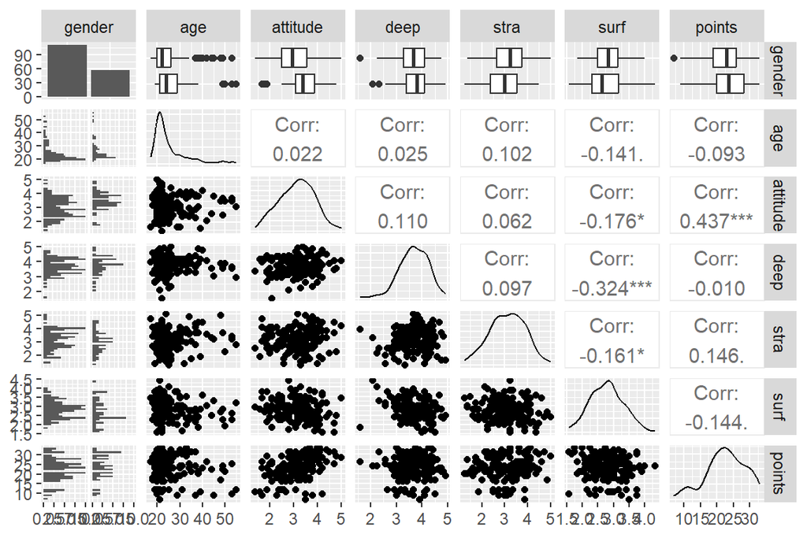

```r
# Now we have a look at this data again with a graphical overview, where we get to look at all the variables plotted against each other and first we install the R packages we will be using.
library(GGally)
library(ggplot2)
library(tidyr)

ggpairs(students2014)
```

```r
summary(students2014)
```

```
##     gender               age           attitude          deep
##  Length:166         Min.   :17.00   Min.   :1.400   Min.   :1.583
##  Class :character   1st Qu.:21.00   1st Qu.:2.600   1st Qu.:3.333
##  Mode  :character   Median :22.00   Median :3.200   Median :3.667
##                     Mean   :25.51   Mean   :3.143   Mean   :3.680
##                     3rd Qu.:27.00   3rd Qu.:3.700   3rd Qu.:4.083
##                     Max.   :55.00   Max.   :5.000   Max.   :4.917
##       stra            surf           points
##  Min.   :1.250   Min.   :1.583   Min.   : 7.00
##  1st Qu.:2.625   1st Qu.:2.417   1st Qu.:19.00
##  Median :3.188   Median :2.833   Median :23.00
##  Mean   :3.121   Mean   :2.787   Mean   :22.72
##  3rd Qu.:3.625   3rd Qu.:3.167   3rd Qu.:27.75
##  Max.   :5.000   Max.   :4.333   Max.   :33.00
```

Here just to test and play around with all the things I am learning, I want to also add colours for each gender and visualise and group data with that too for this I will use ifelse and set a colour for M and F. We get to now observe the exam results of the males(black) and females(red) based on their attitudes in a scatter plot.

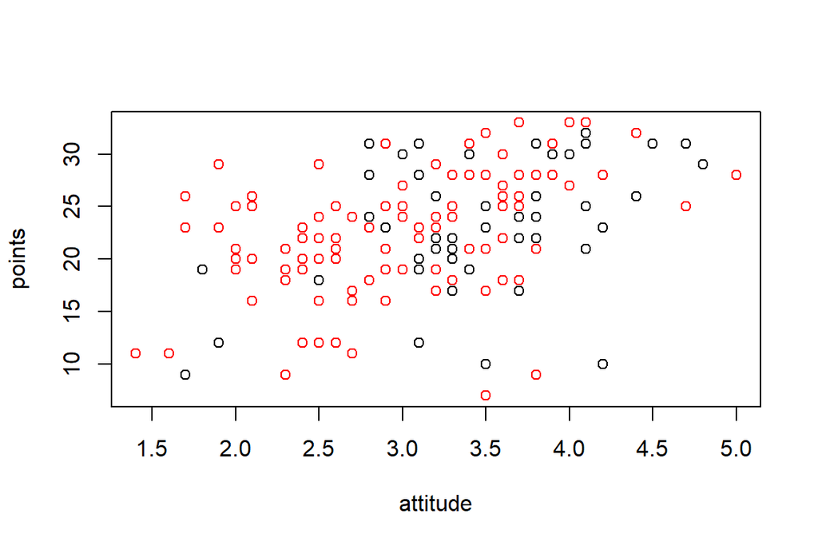

```r
students2014$gender_color <- ifelse(students2014$gender == "M", "black", "red")

plot(students2014$attitude, students2014$points, xlab = "attitude", ylab = "points", col=students2014$gender_color)
```